# Acceleration Tutorial Solutions

Marco Gallegos Herrada and Vinky Wang

```r
# R packages that will be used for this tutorial
library(readr)
library(momentuHMM)
library(ggplot2)
library(dplyr)
library(lubridate)


# Load data
BlacktipB <- read_delim("BlacktipB.txt",
                        delim = "\t", escape_double = FALSE,
                        trim_ws = TRUE)

# Transform into proper time format and take 1-min avg
BlacktipB_1min = BlacktipB %>% filter(ODBA <= 2) %>%
  mutate(Time = as.POSIXct(Time,format = "%m/%d/%Y %H:%M")) %>%
  group_by(Time = floor_date(Time, unit = "1 min")) %>%
  summarise(ODBA_avg = mean(ODBA),
            temp_avg = mean(Temp),
            depth_avg = mean(Depth)) %>%
  ungroup() %>%
  mutate(Time = as.POSIXct(Time,format = "%Y-%m-%d %H:%M:%S")) %>%
  as.data.frame()
```

# Exercise 1

```r
BlacktipBData = prepData(BlacktipB_1min,coordNames = NULL)

mu30 = c(0.05,.09,.12)
sigma30 = c(0.02,.02,.02)
stateNames = c("low-activity","moderate-activity","high-activity")

fit1_s3 <- fitHMM(BlacktipBData,
                       nbState = 3,
                       stateNames = stateNames,
                       dist=list(ODBA_avg="gamma"),
                       Par0 = list(ODBA_avg=c(mu30,sigma30)))

fit1_s3
```

```
## Value of the maximum log-likelihood: 14911.77
##
##
## ODBA_avg parameters:
## --------------------
##      low-activity moderate-activity high-activity
## mean  0.050288793        0.06863295    0.10520417
## sd    0.008207097        0.01305030    0.03089737
##
## Regression coeffs for the transition probabilities:
## ---------------------------------------------------
##                1 -> 2   1 -> 3    2 -> 1    2 -> 3    3 -> 1    3 -> 2
## (Intercept) -2.598401 -4.79957 -2.537834 -2.848565 -5.496522 -1.643738
##
## Transition probability matrix:
## ------------------------------
##                   low-activity moderate-activity high-activity
## low-activity       0.923680221        0.06871485   0.007604925
## moderate-activity  0.069516123        0.87953474   0.050949136
## high-activity      0.003425051        0.16140235   0.835172604
##
## Initial distribution:
## ---------------------
##      low-activity moderate-activity     high-activity
##      9.999987e-01      1.319150e-06      2.029051e-08
```

```
## Decoding state sequence... DONE
```

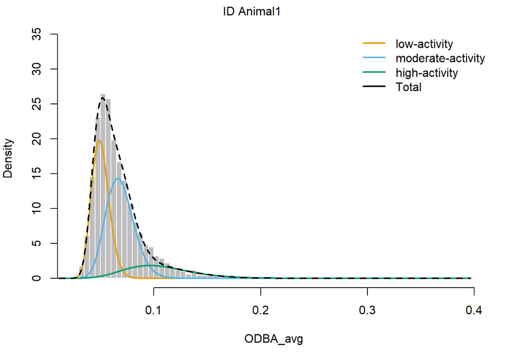

```r
plot(fit1_s3,breaks=80)
```

```
## Computing pseudo-residuals...
```

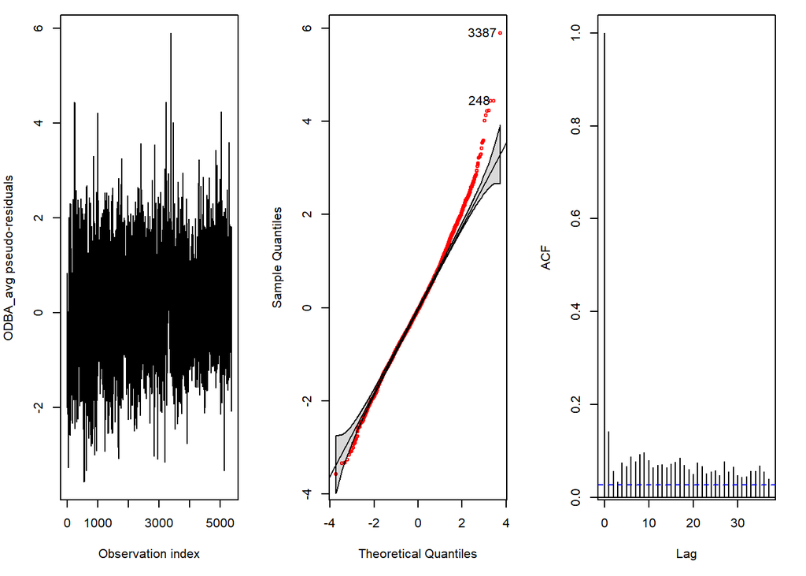

```r
plotPR(fit1_s3)
```

# Exercise 2

**Note:** There are multiple ways to incorporate the other variables into the HMM. Here, we demonstrate how the observed acceleration (i.e., ODBA) can vary depending on the covariates of `temp_avg` and `depth_avg`. In particular, we incorporate `temp_avg` to the mean and `depth_avg` to the standard deviation of the state-dependent Gamma distribution. This is equivalent to allowing for the mean of the 1-minute averaged ODBA values to vary based on the 1-minute averaged temperatures and the variability to vary based on the 1-minute averaged depths.

Returning to the `fit1` example,

```r
BlacktipBData = prepData(BlacktipB_1min,coordNames = NULL)
stateNames = c("low-activity","high-activity") # define names for each state
mu0 = c(.05,.09) # initial values for the mean of each behavioural state
sigma0 = c(.02,.02) # initial values for the standard deviation of each behavioural state
fit1 = fitHMM(BlacktipBData,
              nbStates=2,
              stateNames = stateNames,
              dist=list(ODBA_avg="gamma"),
              Par0 = list(ODBA_avg=c(mu0,sigma0)))

fit1
```

```
## Value of the maximum log-likelihood: 14462.08
##
##
## ODBA_avg parameters:
## --------------------
##      low-activity high-activity
## mean   0.05387998    0.08484691
## sd     0.01008312    0.02486110
##
## Regression coeffs for the transition probabilities:
## ---------------------------------------------------
##                1 -> 2    2 -> 1
## (Intercept) -2.955513 -2.603855
##
## Transition probability matrix:
## ------------------------------
##               low-activity high-activity
## low-activity    0.95052338    0.04947662
## high-activity   0.06889075    0.93110925
##
## Initial distribution:
## ---------------------
##  low-activity high-activity
##  0.9998487757  0.0001512243
```

we prepare the data this time by including these covariate names in `prepData`

```r
# Prep data
BlacktipBData = prepData(BlacktipB_1min,coordNames = NULL, covNames = c("temp_avg", "depth_avg"))
```

and define the design matrix as

```r
temp_avg <- BlacktipBData$temp_avg
depth_avg <- BlacktipBData$depth_avg
DM <- list(ODBA_avg = list(mean = ~temp_avg,
                           sd = ~depth_avg))
```

We use `getPar0` to specify the initial parameters based on the estimated parameters of `fit1`

```r
## Same parameter values from fit1
Par0_fitcov <- getPar0(model = fit1,
                     DM = DM)

fitcov <- fitHMM(BlacktipBData,
                  nbState = 2,
                  dist=list(ODBA_avg="gamma"),
                  Par0 = Par0_fitcov$Par,
                  DM = DM)

fitcov
```

```
## Value of the maximum log-likelihood: 14541.21
##
##
## Regression coeffs for ODBA_avg parameters:
## ------------------------------------------
##      mean_1:(Intercept) mean_1:temp_avg mean_2:(Intercept) mean_2:temp_avg
## [1,]         -0.4636573      -0.0863194          -2.583431     0.004196508
##      sd_1:(Intercept) sd_1:depth_avg sd_2:(Intercept) sd_2:depth_avg
## [1,]        -4.663828    0.008657548        -3.737256     0.01282385
##
## ODBA_avg parameters (based on mean covariate values):
## -----------------------------------------------------
##          state 1    state 2
## mean 0.053992710 0.08508821
## sd   0.009753558 0.02503872
##
## Regression coeffs for the transition probabilities:
## ---------------------------------------------------
##                1 -> 2    2 -> 1
## (Intercept) -2.905089 -2.533488
##
## Transition probability matrix:
## ------------------------------
##            state 1    state 2
## state 1 0.94809743 0.05190257
## state 2 0.07354366 0.92645634
##
## Initial distribution:
## ---------------------
##   state 1   state 2
## 0.5064453 0.4935547
```

We can visualise the estimated mean parameter over the 1-minute averaged temperatures

```
## Decoding state sequence... DONE
```

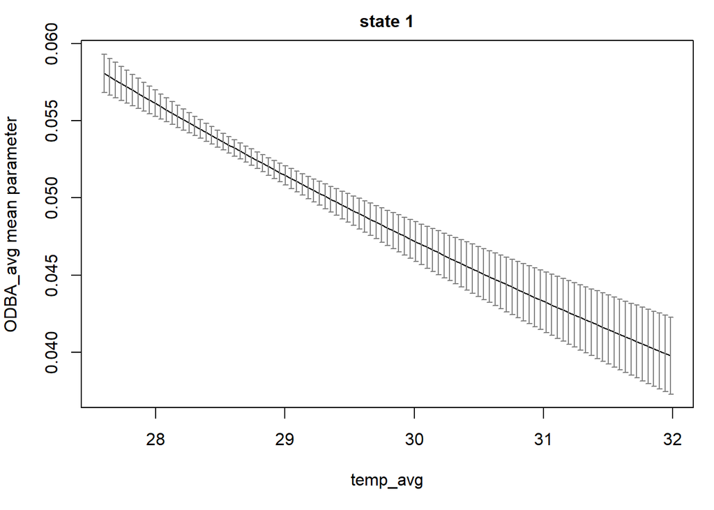

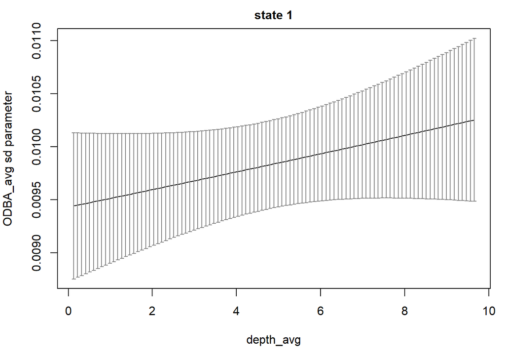

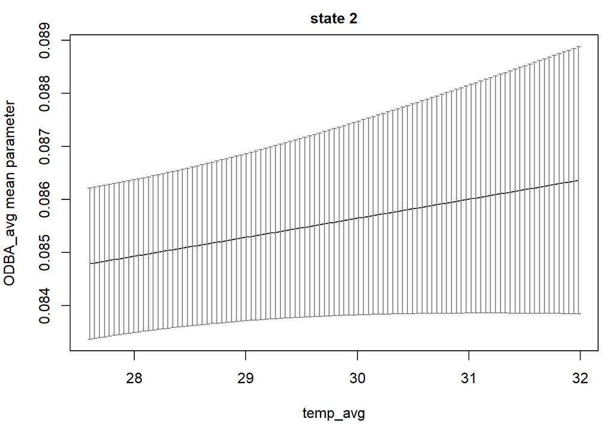

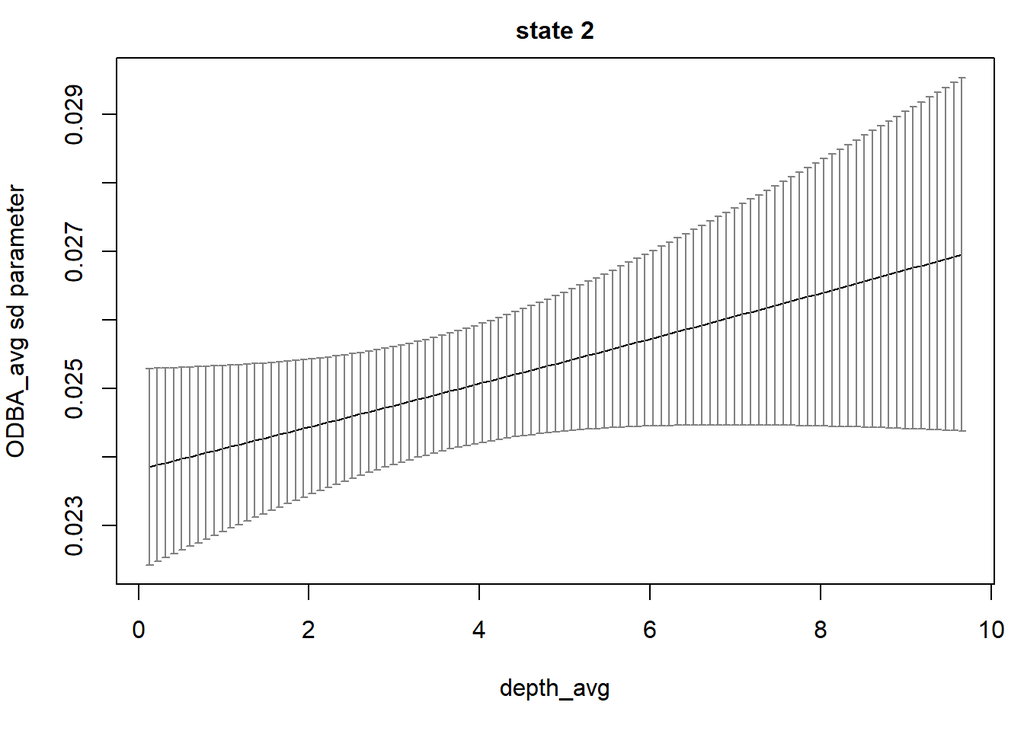

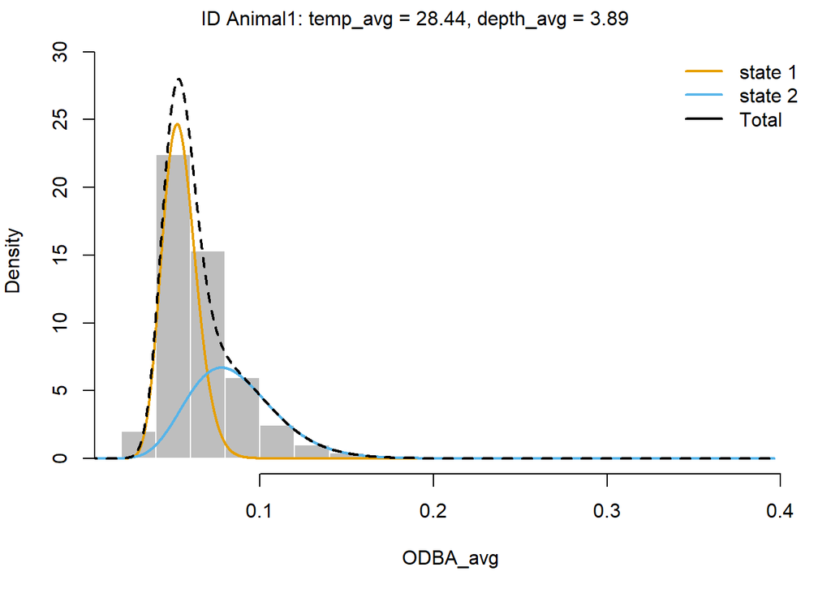

```r
plot(fitcov, ask = F, plotCI = T)
```

We see that for the low-activity state, the mean of the 1-minute averaged ODBA values decrease for increasing 1-minute averaged temperatures and the standard deviation of the 1-minute averaged ODBA values increase for increasing 1-minute averaged depths. For the high-activity state, the mean of the 1-minute averaged ODBA values increase for increasing 1-minute averaged temperatures, however with greater uncertainty compared to the low-activity state. The standard deviation of the 1-minute averaged ODBA values increase for increasing 1-minute averaged depths.

The AIC and the log-likelihood values are -29060.42 and 14541.21.

```r
AIC(fitcov)
```

```
## [1] -29060.42
```

```r
fitcov
```

```
## Value of the maximum log-likelihood: 14541.21
##
##
## Regression coeffs for ODBA_avg parameters:
## ------------------------------------------
##      mean_1:(Intercept) mean_1:temp_avg mean_2:(Intercept) mean_2:temp_avg
## [1,]         -0.4636573      -0.0863194          -2.583431     0.004196508
##      sd_1:(Intercept) sd_1:depth_avg sd_2:(Intercept) sd_2:depth_avg
## [1,]        -4.663828    0.008657548        -3.737256     0.01282385
##
## ODBA_avg parameters (based on mean covariate values):
## -----------------------------------------------------
##          state 1    state 2
## mean 0.053992710 0.08508821
## sd   0.009753558 0.02503872
##
## Regression coeffs for the transition probabilities:
## ---------------------------------------------------
##                1 -> 2    2 -> 1
## (Intercept) -2.905089 -2.533488
##
## Transition probability matrix:
## ------------------------------
##            state 1    state 2
## state 1 0.94809743 0.05190257
## state 2 0.07354366 0.92645634
##
## Initial distribution:
## ---------------------
##   state 1   state 2
## 0.5064453 0.4935547
```